# World Population per Country

220257813

2023-05-14

## Questions

How the population changes over the years for every country? How fast the global population rises? What is the function describing the population?

## Introduction

This document describes an analysis of world population data. The analysis includes an interactive Shiny application that allows users to explore population data for different years.

The question

The data for this analysis were received from [ourworldindata.org](https://ourworldindata.org/world-population-growth). The dataset includes Population data for the years 1950 to 2100 (predictions).

These libraries were used:

- Library `readr` to read CSV files
- Library `stringr` to manipulate strings, and more specifically, to extract countries with specific string characteristics.
- Library `dplyr` to manipulate data for example to summarise, arrange, group, etc.
- Library `ggplot2` for simple plot
- Library `plotly` to display a secondary plot in a separate window for easier zoom in.
- Library `sf` for simple data frame features like read shape file and merge spatial data frame with population data
- Library `leaflet` to create interactive maps and remove shape layers, modify the maps and add polygon layers.
- Library `shiny` for the main graph to be in an interactive window.

## Load and Prepare Data

First, we load the data and preprocess them for our analysis.

With the library `sf` and the function `st_read` the shape file from the directory was read, with the command: `world_sf <- st_read("TM_WORLD_BORDERS_SIMPL-0.3.shp")`

These data needed a preparation before use. First of all the data had columns for several of group ages. Keeping the original data in a safe matrix, the unwanted columns were removed (`Population_Data <- Unmodified_Data[ , 1:3]`). Also, to avoid confusions the name of the *Country* column renamed (`colnames(Population_Data)[1] <- "Country"`). Before proceeding to the graphs, the first and last year should be found, using `min` and `max` functions, as well as the current year using `Sys.Date()` and the step.

## Total Population by Year

This data set had also lines with the population of each continent. So, the total population, can be found by using only the population of these lines. Function `grepl` helped for this preparation, as all these lines had “(UN)” at the end of their name. Then the sum per each year can easily be found with this command: `Sum_by_Year <- aggregate(Population ~ Year, data = Continents, sum)`.

This data set contained predictions for the countries’ population until year 2100. So, it seems more realistic to create a graph with the total population until 2023.

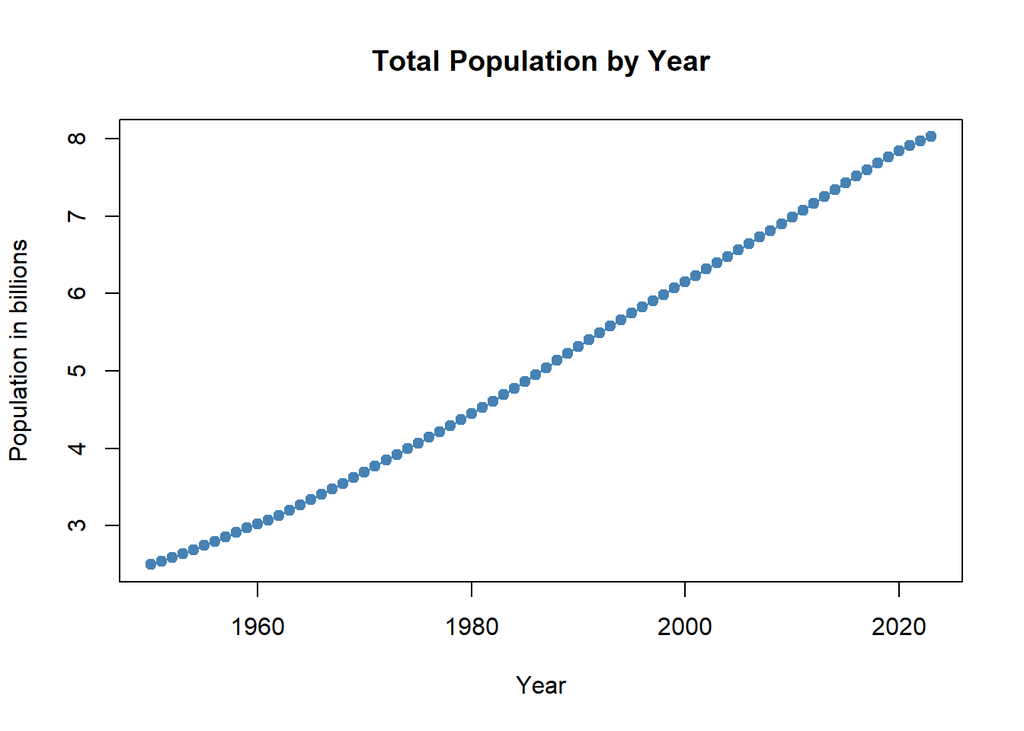

In this graph can be seen that the total population reached 8 billion this year. Only in 1974 the population was half. This means that the global population needed only 49 years to be doubled.

## Interactive Shiny App

This project was primarily designed to visualize population by country over a specific range of years around the current year. To facilitate interactive exploration of this data, the power of the Shiny package in R was used.

The Shiny application contains two components: a User Interface (UI) and a Server function. The UI, defined in the ui object, is the front-end of the application that users interact with. It includes titles, a slider (`sliderInput("yearInput", ...)`) for selecting the year of interest and a leaflet map visualization (`leafletOutput("map", ...)`) that displays the population data by country for the selected year.

## Shiny server

The Server function, on the other hand, is the back-end of the application. It performs the necessary data processing and reactive computations based on user input. When a user moves the slider `yearInput` to select a different year, the Server function self-updates the title to show the total population of the selected year, filters the population data for that year (`Population_Data %>% filter(Year == input$yearInput)`), merges it with the geographic data from the shape file (`merge(world_sf, filtered_data(), by.x = "NAME", by.y = "Country", all.x = TRUE)`), and then updates the map.

Furthermore, inside the observe function the `leaflet` package, and more specifically `leafletProxy("map")` pipeline, uses the `addPolygons` function to add the population data to the map as colored polygons, where the color intensity corresponds to the population magnitude. The map also provides additional information about each country’s population when the cursor goes over it, thanks to the `highlightOptions` and `label` arguments in the `addPolygons` function.

## Run the Shiny app

Finally, the Shiny app is brought to life using the shinyApp() function. This command creates a Shiny app using the defined UI and server. This application is interactive, responding to user inputs and updating the outputs dynamically.

```
##
## Listening on http://127.0.0.1:6798
```

[figure not shown]

## Future

Looking towards future improvements or if time had permitted, an enhancement I would have considered adding a legend to the main interactive map. This addition would help users more intuitively understand the population data being represented, making the application even more user-friendly and informative.

Additionally, I would dedicate more time to further refining the data. In the current state, there are discrepancies between the country names in the original dataset and the shapefile data. By addressing these inconsistencies and ensuring that country names match across all data sources, the quality and accuracy of the visualizations would be significantly enhanced. This would ensure that no relevant data is unintentionally left out from the visualizations due to mismatched country identifiers.

In future studies, I aim to expand this research by including more data from additional years and centuries. This will help to identify a mathematical equation that can accurately describe human population trends over time.

## Refference

Max Roser, Hannah Ritchie, Esteban Ortiz-Ospina and Lucas Rodés-Guirao (2013) - “World Population Growth”. Published online at OurWorldInData.org. Retrieved from: ‘https://ourworldindata.org/world-population-growth’ [Online Resource]